# Please view the html version for interactive pyLDAvis. Alternatively run the cells after installing required dependencies.

```python
import matplotlib.pyplot as plt
import numpy as np
import matplotlib as mpl
import seaborn
import time
mpl.style.use('seaborn-dark')
%matplotlib inline
import pandas as pd
import pprint

#genmsim
import gensim
import gensim.corpora as corpora
from gensim.utils import simple_preprocess
from gensim.models import CoherenceModel
from gensim.test.utils import datapath
from gensim.corpora.dictionary import Dictionary
from gensim.test.utils import datapath

#pyLDAvis
import pyLDAvis
import pyLDAvis.gensim

from wordcloud import WordCloud
import re


import os
os.environ.update({'MALLET_HOME':r'C:/mallet-2.0.8/mallet-2.0.8'})
mallet_path ='C:/mallet-2.0.8/mallet-2.0.8/bin/mallet' # update this path
```

### Part 1: warm-up exercise.

The function below draws a sample from an unnormalised discrete distribution.

1. Explain how it works
2. Write a vectorised version, which takes the number of samples to generate as an extra parameter, and returns a numpy array of samples

```python
def sample_discrete(b):
    r = np.sum(b)*np.random.random();
    a = b[0].copy()
    i = 0
    while a < r:
        i += 1
        a += b[i]
    return i
```

Here's an example of how it works, with probabilities `b`

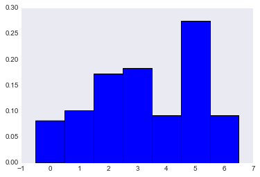

```python
b = np.array([0.1,0.2,0.3,0.4,0.3,0.5,0.2,0.03])
n_samples = 100
bins = np.arange(b.size) - 0.5
samples = np.array([sample_discrete(b) for _ in range(n_samples)])
plt.hist(samples, bins, normed=True)
plt.show()
```

## Answer1

Conclusion: We can see that the vectorized version of sampler is faster than the other two versions and robust to size of input (doesn't give memory error if hypothetical inputs are of million dimensions)

```python
# A simple extension of function above without vectorization

def sample_discrete_multi_novec(b,n): # no vectorization
    sample=np.zeros(n)
    for i in range(n):
        r = np.sum(b)*np.random.random()
        a = b[0].copy()
        j = 0
        while a < r:
            j += 1
            a += b[j]
        sample[i]=j
    return sample
```

```python
# Vectorized function

def sample_discrete_multi_vectorized(b,n):
    r = np.sum(b)*np.random.random(n).reshape(n,1)
    y = r>np.cumsum(b)
    return y.sum(axis=1)
```

```python
# A mini-batch style vectorized sampler robust for hypothetically large input sizes

def fast_sampler(b, n, memory_const=2e9):
    # reasonable memory buffer of 2 giga-BITS = 1/4 giga-BYTE

    # preset output, datatype can be an integer
    ret = np.empty((n,), dtype=int)
    # number of classes
    m = b.size
    # calculate maximum number of samples per mini-batch
    # and make sure n is a integer type (otherwise problems may occur in the next step)
    k = int(memory_const//m) if n*m > memory_const else int(n)
    # loop over number of batches
    for i in range(np.ceil(n/k).astype(int)):
        # check if this batch is too large
        ch = (n<(i+1)*k)
        # number of samples taken
        k_acc = (i+1)*k
        # samples to be taken in this step
        k_step = int(k- ch*(k_acc-n))
        # take the next k or the remaining samples respectively
        ret[k*i:k*i + k_step] = sample_discrete_multi_vectorized(b,k_step)
    return ret
```

```python
#Inputs

#b = np.array([0.1,0.2,0.3,0.4,0.3,0.5,0.2,0.03])
# for hypothetically large size of b and n_samples
b = np.random.random(1000)
n_samples = 100000
```

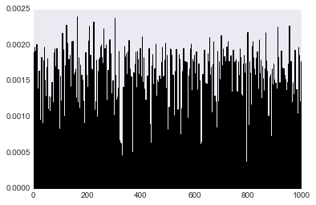

```
sample_discrete takes:  21.34265422821045
```

```python
start = time.time()
samples_1 = np.array([sample_discrete(b) for _ in range(n_samples)])
bins = np.arange(b.size) - 0.5
plt.hist(samples_1, bins, normed=True)
plt.xlim(0,1000)
plt.show()
print('sample_discrete takes: ',time.time()-start)
```

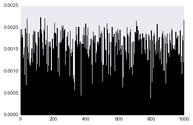

```
sample_discrete_multi_novec takes:  16.248459100723267
```

```python
start = time.time()
samples_2 = sample_discrete_multi_novec(b,n_samples)
bins = np.arange(b.size) - 0.5
plt.hist(samples_2, bins, normed=True)
plt.xlim(0,1000)
plt.show()
print('sample_discrete_multi_novec takes: ', time.time()-start)
```

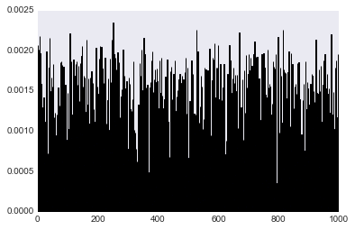

```
fast_sampler takes:  2.8020620346069336
```

```python
start = time.time()
samples_3 = fast_sampler(b,n_samples)
bins = np.arange(b.size) - 0.5
plt.hist(samples_3, bins, normed=True)
plt.xlim(0,1000)
plt.show()
print('fast_sampler takes: ', time.time()-start)
```

# Topic Modeling

This section is about unsupervised learning with text data. We'll be using a relatively small dataset, consisting of 3430 documents and a vocabulary of 6906 words drawn from the daily kos blog around 2004.

You can download the data [here](https://s3-eu-west-1.amazonaws.com/lastmilecoding/exercise.tar.gz).

## Bayesian mixture model

We're going to model the documents as bags of words, with a bayesian mixture model. The documents are modeled using $K$ topics. The assignment of a document to a topic is modeled by the latent variable $z_d$.

The topics are drawn from a categorical distribution with parameters $\theta$, where $\theta$ is drawn from a Dirichlet prior with parameter $\alpha$.

Each topic specifies a categorical distribution over words. The prior on each of these distributions is a Dirichlet with parameter $\gamma$.

The figure below shows this in a graphical model.

[figure not shown]

For simplicity, let's denote with $y_n$ the observations (i.e. the documents we see in the corpus). The conditional likelihood is:

$$p(y_n|z_n \negmedspace = \negmedspace k,\beta) = p(y_n|\beta_k) = p(y_n|\beta_{z_n})$$

And we have a prior:

$$p(\beta_k)$$

And a (latent) categorical assignment probability:

$$p(z_n \negmedspace= \negmedspace k|\theta) = \theta_k$$

which has a Dirichlet prior:

$$p(\theta|\alpha) = Dir(\alpha)$$

Which gives our latent posterior:

$$ p(z_n\negmedspace=\negmedspace k|y_n,\theta,\beta) \quad \propto p(z_n\negmedspace =\negmedspace k|\theta)p(y_n|z_n \negmedspace = \negmedspace k,\beta) \quad \propto \theta_k p(y_n|\beta_{z_n}) $$

### Gibbs Sampling

We will explore this model by drawing from the posterior using MCMC, specifically Gibbs sampling.

We will alternately sample the three types of variables, & iterate this procedure multiple times.

First we'll sample the component parameters:

$$p(\beta_k|y,z) \quad \propto p(\beta_k) \prod_{n:z_n=k} p(y_n|\beta_k) $$

Then the latent allocations of documents to topics: $$ p(z_n \negmedspace= \negmedspace k|y_n,\theta,\beta) \quad \propto \theta_k p(y_n|\beta_{z_n})$$

and then the mixing proportions:

$$p(\theta|z,\alpha) = p(\theta|\alpha)p(z|\theta) = \mathrm{Dir}\left(\frac{c_k+\alpha_k}{\sum_j c_j + \alpha_j}\right)$$

where $c_k$ are the counts for mixture component $k$.

### The Collapsed Gibbs Sampler

We marginalise over $\theta$. (You do not need to derive this result). N.B. the notation $c_{-n}$ indicates all indices *except* $n$.

$$p(z_n \negmedspace= \negmedspace k|z_{-n},\alpha) = \frac{\alpha + c_{-n,k}}{\sum_j \alpha + c_{-n,j}}$$

which gives the *collapsed* gibbs sampler for the latent assignments:

$$p(z_n \negmedspace= \negmedspace k|y_n,z_{-n},\beta,\alpha) \propto p(y_n|\beta_k) \frac{\alpha + c_{-n,k}}{\sum_j \alpha + c_{-n,j}}$$

### Code

The documents have been split into two corpora, `A` and `B`.

The array `words` is a list of all the words in both corpora. The matrices `A` and `B` are the train and test corpora, respectively. Each has 3 columns, there is one row for each unique word in each document.

The first column is the document index, second is the word index (corresponding to `words`), and the third is the number of times that word appears in the document.

```python
# Load datasets and get few dimensions

A = np.load('mat_A.npy')
B = np.load('mat_B.npy')
words = np.load('words.npy')

W = np.max(np.hstack((A[:,1],B[:,1]))) + 1   # number of unique words
D = np.max(A[:,0]) + 1   # number of documents in A
K = 20 # number of mixture components we will use
N = np.sum(A[:,2]) # total number of words in A with repetition
alpha = 10  # parameter of the Dirichlet over mixture components
gamma = 0.1 # parameter of the Dirichlet over words
```

The function below defines the following matrices:

- `sd` : the mixture component assignment of each document
- `swk` : K multinomial distributions over W unique words
- `sk_docs` : the number of documents assigned to each mixture component
- `sk_words` : the number of words assigned to mix component `k` accross all docs

These are initialised by assigning each document to a mixture component at random.

```python
def init():
    sd = np.floor(K*np.random.random((D,1))).astype(int)
    swk = np.zeros((W,K))
    sk_docs = np.zeros((K,1))

    for d in np.arange(D):
        w = A[A[:,0]==d,1]      # unique words in doc d
        c = A[A[:,0]==d,2]      # counts
        k = sd[d]               # doc d is in mixture k
        swk[w,k] = swk[w,k] + c # num times word w is assigned to mixture component k
        sk_docs[k] = sk_docs[k] + 1

    sk_words = np.sum(swk,axis=0).T
    return sd, swk, sk_docs, sk_words
```

The following code starts from this initial state & then performs a number of gibbs sampling sweeps. We will use the collapsed Gibbs sampler, which uses the trick of excluding the current document's counts before calculating the posterior and resampling.

```python
sd, swk, sk_docs, sk_words = init()
num_sweeps = 100
perplexity_iters=np.zeros(num_sweeps)
# This makes a number of Gibbs sampling sweeps through all docs and words
for i_sweep in np.arange(num_sweeps):
    print("gibbs sweep : {0}".format(i_sweep))
    for d in np.arange(D):
        w = A[A[:,0]==d,1]      # unique words in doc d
        c = A[A[:,0]==d,2]      # counts

        # remove doc d's contributions from count tables
        swk[w,sd[d]] = swk[w,sd[d]] - c
        sk_docs[sd[d]] = sk_docs[sd[d]] - 1
        sk_words[sd[d]] = sk_words[sd[d]] - np.sum(c)

        # log probability of doc d under each mixture component
        lb = np.zeros(K)
        for k in np.arange(K):
            ll = np.dot(c,( np.log(swk[w,k]+gamma) - np.log(sk_words[k] + gamma*W) ))
            lb[k] = np.log(sk_docs[k] + alpha) + ll

        # assign doc d to a new component
        b = np.exp(lb-np.max(lb))
        kk = sample_discrete(b)

        # add back doc d's contributions from count tables
        swk[w,kk] = swk[w,kk] + c
        sk_docs[kk] = sk_docs[kk] + 1
        sk_words[kk] = sk_words[kk] + np.sum(c)
        sd[d] = kk

    # per word-perplexity of the test corpus B per every gibbs sweep
    lp = 0; nd = 0
    doc_B = np.unique(B[:,0])
    for d in range(2000,2000+len(doc_B)):
        w = B[B[:,0]==d,1]    #unique words in doc d
        c = B[B[:,0]==d,2]    # counts
        u = np.log(sk_docs[:] + alpha) - np.log(np.sum(sk_docs[:])+alpha)
        for k in range(K):
            b = (swk[:,k]+gamma)/(sk_words[k] + gamma*W)
            u[k] = u[k] + np.dot(c,np.log(b[w]))
        lp = lp + np.log(np.sum(np.exp(u-np.max(u))))+ np.max(u)
        nd = nd + np.sum(c)  # number of words, doc d

    perplexity_iters[i_sweep] = np.exp(-lp/nd) # perplexity
```

```
gibbs sweep : 0
gibbs sweep : 1
gibbs sweep : 2
gibbs sweep : 3
gibbs sweep : 4
gibbs sweep : 5
gibbs sweep : 6
gibbs sweep : 7
gibbs sweep : 8
gibbs sweep : 9
gibbs sweep : 10
gibbs sweep : 11
gibbs sweep : 12
gibbs sweep : 13
gibbs sweep : 14
gibbs sweep : 15
gibbs sweep : 16
gibbs sweep : 17
gibbs sweep : 18
gibbs sweep : 19
gibbs sweep : 20
gibbs sweep : 21
gibbs sweep : 22
gibbs sweep : 23
gibbs sweep : 24
gibbs sweep : 25
gibbs sweep : 26
gibbs sweep : 27
gibbs sweep : 28
gibbs sweep : 29
gibbs sweep : 30
gibbs sweep : 31
gibbs sweep : 32
gibbs sweep : 33
gibbs sweep : 34
gibbs sweep : 35
gibbs sweep : 36
gibbs sweep : 37
gibbs sweep : 38
gibbs sweep : 39
```

[output cut: 45 more lines]

```
gibbs sweep : 85
gibbs sweep : 86
gibbs sweep : 87
gibbs sweep : 88
gibbs sweep : 89
gibbs sweep : 90
gibbs sweep : 91
gibbs sweep : 92
gibbs sweep : 93
gibbs sweep : 94
gibbs sweep : 95
gibbs sweep : 96
gibbs sweep : 97
gibbs sweep : 98
gibbs sweep : 99
```

The plot below shows that the perplexity of the test corpus B is decreasing by gibbs sweeps.

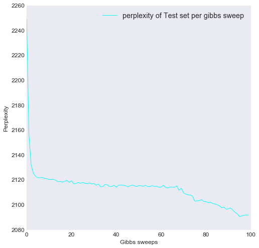

```python
plt.figure(figsize=(8,8))
plt.rcParams.update({'font.size': 12})
plt.plot(perplexity_iters, label= 'perplexity of Test set per gibbs sweep', color = 'cyan' )
#plt.title("perplexity vs Gibs sweeps")
plt.xlabel("Gibbs sweeps")
plt.ylabel("Perplexity")
#plt.ylim(0,8000)
#plt.ylim(-5500, 8000)
#plt.xlim(2000,3500)
plt.legend()
```

## Part 2:

1. Explain what the code above does. Are you happy with this model? What are its deficiencies?
2. Calculate the log probability of the first document in corpus B. What does this number mean?
3. Calculate the per-word perplexity of the test corpus. What does this number mean? Is it good?

Answers:

1ans. The code above is a variant of Topic modeling task, where a collections of documents are modeled into various topics. It is a bayesian mixture model where observations are entire documents with collapsed gibbs sampling, a randomized statistical inference algorithm. It models each document (2000 of them) as a single topic (20 of them).

I am not happy with the default model. It had to be run for more iterations (default 10) to reduce perplexity of test corpus B as seen from figure above. Also, to check robustness of the above model, it needs to be run for different topic(K) values and perplexity on training and test tests needs to compared (choose the one with lower perplexity). In addition the hyperparamters alpha and gamma could be tuned using a grid search and perplexity as evaluation metric

```
This bayesian mixture model doesn't capture the phenomenon of a mixed membership model like LDA, where a document is associated with a collection of topics. This model may not be good for generalization on new unseen data.
```

2ans. The log probablitiy of the first document in corpus B is -3620.015. The goodness-of-fit of a model is evaluated using log probablity of held-out or test documents that are not used for training. (another way to do it is using perplexity)

3ans. In text modeling, per word perplexity is a measure of the performance. Lower value of perplexity indicate lower misrepresentaion of words of the test documentss by trained topics. The per-word perplixity of the test corpus B is 2122.42. For common words the perplexity would be small and for rear words high. This is reason different documents have different perplexity values.

References:

http://acsweb.ucsd.edu/~yuw176/report/lda.pdf

https://cacm.acm.org/magazines/2012/4/147361-probabilistic-topic-models/fulltext

https://stats.stackexchange.com/questions/120031/in-lda-how-to-interpret-the-meaning-of-topics

```python
# log probablitiy of first document in corpus B
lp = 0
w = B[B[:,0]==2000,1]    #unique words in doc d
c = B[B[:,0]==2000,2]    # counts
z = np.log(sk_docs[:] + alpha) - np.log(np.sum(sk_docs[:])+alpha)
for k in range(K):
    b = (swk[:,k]+gamma)/(sk_words[k] + gamma*W)
    z[k] = z[k] + np.dot(c,np.log(b[w]))
lp = lp + np.log(np.sum(np.exp(z-np.max(z))))+ np.max(z)
```

```python
# output: log probablitiy of first document in corpus B
lp
```

```
-3620.014769561022
```

```python
# per word-perplexity of the test corpus B
lp = 0; nd = 0
doc_B = np.unique(B[:,0])
for d in range(2000,2000+len(doc_B)):
    w = B[B[:,0]==d,1]    #unique words in doc d
    c = B[B[:,0]==d,2]    # counts
    u = np.log(sk_docs[:] + alpha) - np.log(np.sum(sk_docs[:])+alpha)
    for k in range(K):
        b = (swk[:,k]+gamma)/(sk_words[k] + gamma*W)
        u[k] = u[k] + np.dot(c,np.log(b[w]))
    lp = lp + np.log(np.sum(np.exp(u-np.max(u))))+ np.max(u)
    nd = nd + np.sum(c)  # number of words, doc d
```

```python
perplexity_bmm = np.exp(-lp/nd)
perplexity_bmm  #perplexity of the text corpus B
```

```
2122.4229272842076
```

## Part 3:

Free form. Extend and/or analyse the above model, or use your favourite algorithm to find something interesting in this dataset. Show us what you can do!

# Modeling using LDA model from gensim

LDA from gensim is implemented using online variational deterministic method called online LDA.

https://papers.nips.cc/paper/3902-online-learning-for-latent-dirichlet-allocation

```python
#convert the input dataset into a list of all documents with texts (not ids) in the corpus
text_all=[]
for d in range(2000):
    T_new_list=[]
    T=A[A[:,0]==d,1:3] # document one
    for i in range(T.shape[0]):
        for j in range(T[i,1]):
            T_new_list.append(words[T[i,0]])
    text_all.append(T_new_list)
```

```python
# Create id2word from a list of texts i.e. corpus
id2word = Dictionary(text_all)
```

```python
# Create the BOW corpus
corpus = [id2word.doc2bow(text) for text in text_all]
```

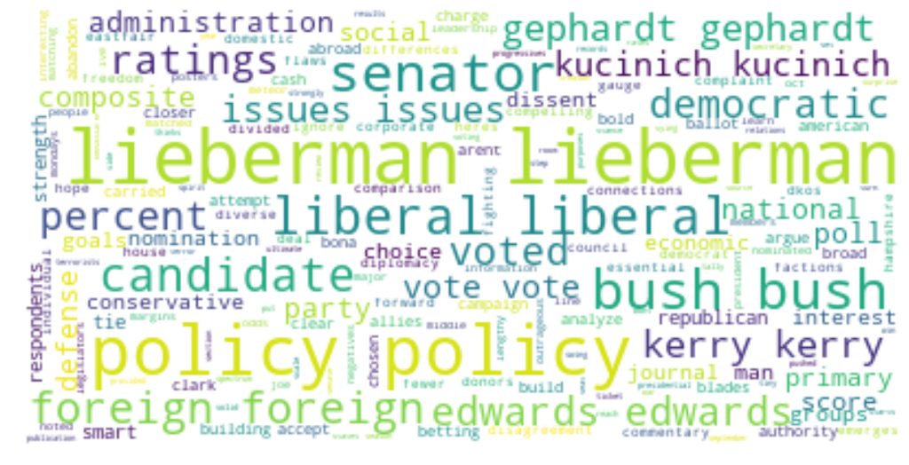

```python
# Visualization: Generate word cloud for first document in corpus A

wordcloud = WordCloud(max_font_size=40, background_color = 'white').generate('-'.join(text_all[0]))
plt.figure(figsize=(18, 18))
plt.imshow(wordcloud, interpolation="bilinear")
plt.axis("off")
plt.show()
```

```python
# Build the model
lda_model = gensim.models.ldamodel.LdaModel(corpus=corpus,id2word=id2word,num_topics=20, random_state=100,update_every=1,chunksize=2000,passes=10,alpha='auto',
                                           per_word_topics=True)
```

```python
# View topics in the model.
# The key words for each topic can be seen with their importance or weightage.
lda_model.print_topics(20)
```

```
[(0,
  '0.040*"bush" + 0.021*"kerry" + 0.011*"president" + 0.009*"administration" + 0.008*"general" + 0.007*"iraq" + 0.007*"people" + 0.007*"war" + 0.005*"bushs" + 0.005*"time"'),
 (1,
  '0.010*"time" + 0.007*"dkos" + 0.005*"political" + 0.005*"campaign" + 0.005*"blog" + 0.004*"people" + 0.004*"house" + 0.004*"community" + 0.004*"million" + 0.004*"senate"'),
 (2,
  '0.043*"kerry" + 0.031*"dean" + 0.026*"edwards" + 0.024*"poll" + 0.019*"primary" + 0.018*"clark" + 0.015*"democratic" + 0.012*"polls" + 0.011*"bush" + 0.011*"gephardt"'),
 (3,
  '0.016*"bush" + 0.011*"campaign" + 0.008*"kerry" + 0.007*"house" + 0.007*"nader" + 0.006*"media" + 0.006*"state" + 0.005*"bushs" + 0.005*"republican" + 0.005*"national"'),
 (4,
  '0.029*"bush" + 0.008*"tax" + 0.008*"administration" + 0.007*"president" + 0.005*"bushs" + 0.005*"reagan" + 0.005*"kerry" + 0.005*"billion" + 0.005*"republicans" + 0.005*"general"'),
 (5,
  '0.013*"bush" + 0.012*"campaign" + 0.009*"democratic" + 0.009*"party" + 0.009*"republican" + 0.008*"money" + 0.008*"million" + 0.008*"republicans" + 0.007*"democrats" + 0.007*"news"'),
 (6,
  '0.021*"dean" + 0.010*"kerry" + 0.009*"democratic" + 0.008*"primary" + 0.008*"caucus" + 0.007*"edwards" + 0.006*"iowa" + 0.006*"vote" + 0.006*"delegates" + 0.005*"people"'),
 (7,
  '0.012*"bush" + 0.010*"administration" + 0.008*"war" + 0.008*"iraq" + 0.004*"terrorism" + 0.004*"officials" + 0.004*"abu" + 0.004*"political" + 0.004*"house" + 0.004*"election"'),
 (8,
  '0.014*"campaign" + 0.013*"million" + 0.013*"bunning" + 0.010*"kerry" + 0.009*"democratic" + 0.007*"elections" + 0.007*"mongiardo" + 0.006*"district" + 0.006*"money" + 0.006*"senate"'),
 (9,
  '0.013*"bush" + 0.008*"war" + 0.007*"iraq" + 0.005*"campaign" + 0.005*"people" + 0.005*"democratic" + 0.004*"rights" + 0.004*"years" + 0.004*"president" + 0.004*"bushs"'),
 (10,
  '0.014*"states" + 0.012*"state" + 0.011*"party" + 0.011*"democratic" + 0.011*"voters" + 0.011*"bush" + 0.009*"general" + 0.008*"republican" + 0.008*"election" + 0.008*"kerry"'),
 (11,
  '0.026*"percent" + 0.016*"race" + 0.015*"senate" + 0.014*"bush" + 0.013*"poll" + 0.010*"republican" + 0.009*"kerry" + 0.009*"voters" + 0.009*"state" + 0.007*"election"'),
 (12,
  '0.015*"bush" + 0.013*"war" + 0.012*"iraq" + 0.008*"administration" + 0.006*"house" + 0.005*"people" + 0.005*"intelligence" + 0.004*"government" + 0.004*"national" + 0.004*"american"'),
 (13,
  '0.039*"iraq" + 0.024*"war" + 0.014*"iraqi" + 0.010*"american" + 0.010*"military" + 0.008*"forces" + 0.008*"baghdad" + 0.007*"saddam" + 0.007*"soldiers" + 0.007*"killed"'),
 (14,
  '0.017*"bush" + 0.009*"iraq" + 0.007*"white" + 0.006*"general" + 0.006*"news" + 0.005*"president" + 0.005*"war" + 0.005*"military" + 0.005*"house" + 0.005*"people"'),
 (15,
  '0.058*"november" + 0.013*"poll" + 0.012*"house" + 0.011*"republicans" + 0.011*"polls" + 0.011*"electoral" + 0.011*"senate" + 0.011*"account" + 0.011*"governor" + 0.009*"turnout"'),
 (16,
  '0.013*"house" + 0.010*"delay" + 0.007*"democrats" + 0.007*"campaign" + 0.006*"democratic" + 0.005*"time" + 0.005*"herseth" + 0.005*"dean" + 0.005*"candidates" + 0.005*"elections"'),
 (17,
  '0.008*"house" + 0.006*"keyes" + 0.006*"gop" + 0.006*"people" + 0.005*"election" + 0.005*"bush" + 0.005*"delay" + 0.005*"republican" + 0.005*"elections" + 0.005*"issue"'),
 (18,
  '0.049*"november" + 0.014*"voting" + 0.013*"bush" + 0.013*"kerry" + 0.011*"house" + 0.011*"vote" + 0.011*"republicans" + 0.010*"senate" + 0.010*"poll" + 0.010*"account"'),
 (19,
  '0.010*"cheney" + 0.009*"bush" + 0.006*"president" + 0.005*"war" + 0.005*"poll" + 0.005*"iraq" + 0.005*"time" + 0.005*"house" + 0.005*"alexander" + 0.005*"general"')]
```

```python
# Save model to disk.
temp_file = datapath("model")
lda_model.save(temp_file)
# Load a pretrained model from disk.
lda_model = lda_model.load(temp_file)
```

```python
# Compute Perplexity
# a measure of how good the model is. lower the better.

print('\nPerplexity: ', lda_model.log_perplexity(corpus))

# Compute Coherence Score (higher the better)
# could be used similar to perplexity to choose number of topics, when topics vs coherence score is plotted

coherence_model_lda = CoherenceModel(model=lda_model, texts=text_all, dictionary=id2word, coherence='c_v')
coherence_lda = coherence_model_lda.get_coherence()
print('\nCoherence Score: ', coherence_lda)
```

```
Perplexity:  -7.87172745230938

Coherence Score:  0.27715338349244445
```

Interpretation:

1. Larger the bubble more prevalent the topic.
2. A good model is representative of fairly big non-overlapping bubbles scattered (instead of being in one quadrant)
3. If model is asked to give out too many topics, it will have many overlaps and clustering of topics in a quadrant.

Scope: The optimal number of topics could be dervied by plotting coherance score vs number of topics or by using a heirarchical dirichlet process

https://datascience.stackexchange.com/questions/128/latent-dirichlet-allocation-vs-hierarchical-dirichlet-process

Conclusion: We can observe that the gensim LDA is not good in comparision to the mallet LDA (see below) as the latter has topics scattered with relatively less overlapping

```python
# Visualization: We can see the topics produced and associated key words interactively.
pyLDAvis.enable_notebook()
vis = pyLDAvis.gensim.prepare(lda_model, corpus, id2word)
vis
```

[interactive chart not shown]

```python
def format_topics_sentences(ldamodel=lda_model, corpus=corpus, texts=text_all):
    # Init output
    sent_topics_df = pd.DataFrame()

    # Get main topic in each document
    for i, row in enumerate(ldamodel[corpus]):
        row = sorted(row[0], key=lambda x: (x[1]), reverse=True)
        # Get the Dominant topic, Perc Contribution and Keywords for each document
        for j, (topic_num, prop_topic) in enumerate(row):
            if j == 0:  # => dominant topic
                wp = ldamodel.show_topic(topic_num)
                topic_keywords = ", ".join([word for word, prop in wp])
                sent_topics_df = sent_topics_df.append(pd.Series([int(topic_num), round(prop_topic,4), topic_keywords]), ignore_index=True)
            else:
                break
    sent_topics_df.columns = ['Dominant_Topic', 'Perc_Contribution', 'Topic_Keywords']

    # Add original text to the end of the output
    contents = pd.Series(texts)
    sent_topics_df = pd.concat([sent_topics_df, contents], axis=1)
    return(sent_topics_df)


df_topic_sents_keywords = format_topics_sentences(ldamodel=lda_model, corpus=corpus, texts=text_all)

# Format
df_dominant_topic = df_topic_sents_keywords.reset_index()
df_dominant_topic.columns = ['Document_No', 'Dominant_Topic', 'Topic_Perc_Contrib', 'Keywords', 'Text']
```

```python
# shows the dominant topic in each document.
df_dominant_topic.head(10)
```

|  | Document_No | Dominant_Topic | Topic_Perc_Contrib | Keywords | Text |
| --- | --- | --- | --- | --- | --- |
| 0 | 0 | 2.0 | 0.3270 | kerry, dean, edwards, poll, primary, clark, de... | [abandon, abroad, accept, administration, admi... |
| 1 | 1 | 2.0 | 0.7943 | kerry, dean, edwards, poll, primary, clark, de... | [accuracy, ballots, call, call, called, caucus... |
| 2 | 2 | 15.0 | 0.9708 | november, poll, house, republicans, polls, ele... | [abu, account, account, admin, administration,... |
| 3 | 3 | 18.0 | 0.9970 | november, voting, bush, kerry, house, vote, re... | [account, account, add, admin, advertising, al... |
| 4 | 4 | 14.0 | 0.4901 | bush, iraq, white, general, news, president, w... | [allegiance, america, america, america, americ... |
| 5 | 5 | 16.0 | 0.4813 | house, delay, democrats, campaign, democratic,... | [america, boston, calls, convention, country, ... |
| 6 | 6 | 11.0 | 0.7229 | percent, race, senate, bush, poll, republican,... | [accomplish, added, area, avoid, bank, battleg... |
| 7 | 7 | 16.0 | 0.5360 | house, delay, democrats, campaign, democratic,... | [accomplish, add, added, amazing, ambitious, a... |
| 8 | 8 | 0.0 | 0.9870 | bush, kerry, president, administration, genera... | [added, administration, administration, amazin... |
| 9 | 9 | 10.0 | 0.5633 | states, state, party, democratic, voters, bush... | [agrees, americans, announced, arnold, attempt... |

# Modeling using LDA (with collapsed gibbs sampling from mallet+gensim wrapper)

Mallet LDA implementation is well optimized for multicore support and is more accurate fitting than variational bayes variant see in Gensim lDA.

http://mallet.cs.umass.edu/topics.php

```python
ldamallet = gensim.models.wrappers.LdaMallet(mallet_path, corpus=corpus, num_topics=20, id2word=id2word)
```

```python
# Save model to disk.
temp_file_mallet = datapath("model_mallet")
ldamallet.save(temp_file_mallet)
# Load a potentially pretrained model from disk.
ldamallet = ldamallet.load(temp_file_mallet)
```

```python
# Compute Coherence Score (higher the better)
# could be used similar to perplexity to choose number of topics, when topics vs coherence score is plotted
coherence_model_ldamallet = CoherenceModel(model=ldamallet, texts=text_all, dictionary=id2word, coherence='c_v')
coherence_ldamallet = coherence_model_ldamallet.get_coherence()
print('\nCoherence Score: ', coherence_ldamallet)
```

```
Coherence Score:  0.3552644990228132
```

```python
pprint.pprint(ldamallet.show_topics(formatted=False))
```

```
[(2,
  [('people', 0.044347235839806924),
   ('america', 0.016818764612715892),
   ('women', 0.013500263971641904),
   ('man', 0.011690172712874274),
   ('politics', 0.011690172712874274),
   ('country', 0.01146391130552832),
   ('american', 0.011086808959951731),
   ('important', 0.010181763330567917),
   ('americans', 0.009125876762953466),
   ('public', 0.009050456293838148)]),
 (4,
  [('dean', 0.06634673979280926),
   ('edwards', 0.048446069469835464),
   ('primary', 0.04524680073126142),
   ('democratic', 0.04349482023156612),
   ('kerry', 0.03884826325411334),
   ('clark', 0.031687995124923825),
   ('iowa', 0.023918342474101156),
   ('gephardt', 0.021937842778793418),
   ('lieberman', 0.01683424741011578),
   ('poll', 0.014396709323583182)]),
 (14,
  [('year', 0.017921710422889484),
   ('tax', 0.016664046533563907),
   ('jobs', 0.01642823455431536),
   ('years', 0.014227322747995598),
   ('economy', 0.013677094796415658),
   ('billion', 0.011790598962427292),
   ('job', 0.011633390976261595),
   ('economic', 0.011554786983178746),
   ('cut', 0.009275271183776137),
   ('federal', 0.008882251218361894)]),
 (13,
  [('media', 0.031012836128548674),
   ('local', 0.019301040007495548),
   ('tom', 0.0191136512695587),
   ('news', 0.01892626253162185),
   ('people', 0.0179893188419376),
   ('schaller', 0.01255504544176895),
```

[output cut: 55 more lines]

```
   ('time', 0.009619371423832821),
   ('piece', 0.009453520192387429),
   ('ill', 0.009121817729496641),
   ('page', 0.008790115266605855)]),
 (1,
  [('senate', 0.05380648663319311),
   ('race', 0.03555434930112634),
   ('elections', 0.029311982629936218),
   ('house', 0.02625865110598453),
   ('state', 0.022730356900529245),
   ('district', 0.02083050617451486),
   ('republican', 0.01988058081150767),
   ('gop', 0.018319989143710136),
   ('seat', 0.017030804722486092),
   ('races', 0.015673768489618673)])]
```

```python
lda_model_2 = gensim.models.wrappers.ldamallet.malletmodel2ldamodel(ldamallet)
pyLDAvis.enable_notebook()
vis = pyLDAvis.gensim.prepare(lda_model_2, corpus, id2word)
vis
```

[interactive chart not shown]

```python
def format_topics_sentences(ldamodel=lda_model_2, corpus=corpus, texts=text_all):
    # Init output
    sent_topics_df = pd.DataFrame()

    # Get main topic in each document
    for i, row in enumerate(lda_model_2[corpus]):
        row = sorted(row, key=lambda x: (x[1]), reverse=True)
        # Get the Dominant topic, Perc Contribution and Keywords for each document
        for j, (topic_num, prop_topic) in enumerate(row):
            if j == 0:  # => dominant topic
                wp = lda_model_2.show_topic(topic_num)
                topic_keywords = ", ".join([word for word, prop in wp])
                sent_topics_df = sent_topics_df.append(pd.Series([int(topic_num), round(prop_topic,4), topic_keywords]), ignore_index=True)
            else:
                break
    sent_topics_df.columns = ['Dominant_Topic', 'Perc_Contribution', 'Topic_Keywords']

    # Add original text to the end of the output
    contents = pd.Series(texts)
    sent_topics_df = pd.concat([sent_topics_df, contents], axis=1)
    return(sent_topics_df)


df_topic_sents_keywords = format_topics_sentences(ldamodel=lda_model_2, corpus=corpus, texts=text_all)

# Format
df_dominant_topic = df_topic_sents_keywords.reset_index()
df_dominant_topic.columns = ['Document_No', 'Dominant_Topic', 'Topic_Perc_Contrib', 'Keywords', 'Text']
```

```python
# shows the dominant topic in each document.
df_dominant_topic.head(20)
```

|  | Document_No | Dominant_Topic | Topic_Perc_Contrib | Keywords | Text |
| --- | --- | --- | --- | --- | --- |
| 0 | 0 | 5.0 | 0.1939 | dean, primary, edwards, democratic, kerry, cla... | [abandon, abroad, accept, administration, admi... |
| 1 | 1 | 5.0 | 0.2871 | dean, primary, edwards, democratic, kerry, cla... | [accuracy, ballots, call, call, called, caucus... |
| 2 | 2 | 6.0 | 0.6632 | november, governor, account, electoral, republ... | [abu, account, account, admin, administration,... |
| 3 | 3 | 6.0 | 0.5164 | november, governor, account, electoral, republ... | [account, account, add, admin, advertising, al... |
| 4 | 4 | 4.0 | 0.1462 | people, politics, man, issue, political, side,... | [allegiance, america, america, america, americ... |
| 5 | 5 | 17.0 | 0.0962 | national, service, white, years, texas, guard,... | [america, boston, calls, convention, country, ... |
| 6 | 6 | 2.0 | 0.2313 | states, win, state, election, democrats, vote,... | [accomplish, added, area, avoid, bank, battleg... |
| 7 | 7 | 7.0 | 0.2676 | senate, house, elections, race, district, repu... | [accomplish, add, added, amazing, ambitious, a... |
| 8 | 8 | 14.0 | 0.2037 | administration, house, report, bush, white, in... | [added, administration, administration, amazin... |
| 9 | 9 | 3.0 | 0.4077 | republicans, republican, state, democrats, law... | [agrees, americans, announced, arnold, attempt... |
| 10 | 10 | 1.0 | 0.2253 | bush, kerry, general, president, john, kerrys,... | [avoid, base, bigger, bush, bush, bush, bush, ... |
| 11 | 11 | 7.0 | 0.2518 | senate, house, elections, race, district, repu... | [added, ads, advertiser, advertiser, air, alon... |
| 12 | 12 | 1.0 | 0.1836 | bush, kerry, general, president, john, kerrys,... | [abc, abcs, affiliates, bad, bush, bush, bushs... |
| 13 | 13 | 6.0 | 0.5587 | november, governor, account, electoral, republ... | [account, account, add, admin, administration,... |
| 14 | 14 | 0.0 | 0.1939 | media, news, blog, convention, times, coverage... | [action, apparently, atrios, atrios, atrios, a... |
| 15 | 15 | 16.0 | 0.2535 | iraq, war, iraqi, military, american, troops, ... | [abuse, abuses, aid, allied, american, america... |
| 16 | 16 | 6.0 | 0.3264 | november, governor, account, electoral, republ... | [account, account, accountability, added, admi... |
| 17 | 17 | 7.0 | 0.2378 | senate, house, elections, race, district, repu... | [accusations, alleged, allen, alongside, arg, ... |
| 18 | 18 | 14.0 | 0.4876 | administration, house, report, bush, white, in... | [accusations, action, activities, administrati... |
| 19 | 19 | 10.0 | 0.1313 | campaign, debate, question, press, asked, ques... | [beauprez, begun, bush, bush, calm, candidate,... |